# Trabajo Práctico

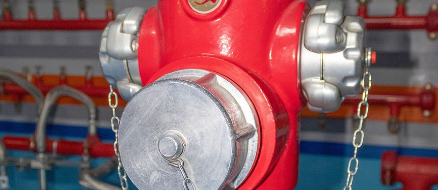

Hidrante. Fuente: iberext.com

### Diseño de una red contra incendio industrial

Una planta industrial necesita instalar una red contra incendio de agua presurizada.

La instalación deberá permitir alimentar simultáneamente:

- 3 hidrantes con mangueras de 1½”
- presión mínima requerida en cada hidrante: 3 bar

La red cuenta básicamente con una cañería troncal principal y derivaciones cortas hacia cada hidrante.

> Este trabajo tiene fines didácticos y no busca cumplir normas específicas reales de instalaciones contra incendio.

#### Datos de la instalación

- Distancia desde la bomba hasta el hidrante más alejado: 90 m
- Diferencia de altura entre la bomba y el hidrante más elevado: Ninguna, todo está aproximadamente al mismo nivel
- Material de las cañerías: a elección propia

**Esquema de planta:**

Se supone que el caño troncal sale de la bomba y va por arriba a unos 6 metros de altura. En cada hidrante baja un caño desde el troncal.

[figure not shown]

#### Se pide

**Parte 1 – Diseño hidráulico**

Asumir que cada hidrante consume 250 L/min y que funcionan en froma simultánea.

Una buena práctica de la ingeniería hidráulica internacional (NFPA) es considerar:

- Velocidad máxima de diseño recomendada: Se estila no superar los 3 m/s a 4,5 m/s en cañerías principales para mantener las pérdidas de carga en niveles aceptables.
- Velocidad límite absoluta en emergencias: En tramos terminales o ante la apertura máxima del sistema, se tolera técnicamente un techo de hasta 6 m/s.

Adopta una velocidad que te parezca aceptable y justifíca.

1. Determinar el caudal total de diseño.
2. Definir velocidades de circulación adecuadas.
3. Calcular los diámetros internos necesarios.
4. Seleccionar diámetros comerciales reales disponibles en Argentina.

**Parte 2 – Pérdidas de carga**

Para esto considerar el tramo más desfavorable que es entre la bomba y el hidrante más alejado.

6. Calcular pérdidas de carga por fricción en cada parte que compone el tramo total usando la fórmula de Hazen Williams.
7. Determinar la pérdida del tramo total del sistema (sumar la que corresponde a cada parte).
8. Calcular pérdidas localizadas como porcentaje.
9. Determinar la presión mínima requerida en la bomba.

**Parte 3 – Selección comercial**

10. Buscar en el mercado argentino: caños, hidrantes, y bomba. Registrar:
- marca,
- modelo,
- diámetro,
- material,
- presión nominal,
- precio aproximado,
- y fuente consultada.
11. Elaborar un presupuesto aproximado de la instalación.

**Parte 4 – Análisis técnico**

13. Justificar técnicamente: elección de materiales, elección de diámetros, elección de bomba.
14. Analizar:
- cómo afecta el diámetro de la troncal a las pérdidas de carga,
- cómo afecta al costo,
- y qué compromiso existe entre costo inicial y desempeño hidráulico.
15. Indicar si sería conveniente utilizar variador de frecuencia y justificar.

**Parte 5 - Defensa oral**

Para aprobar el trabajo práctico se deberá:

- defender oralmente el diseño realizado,
- justificar las decisiones técnicas,
- responder preguntas sobre cálculos y selección de componentes,
- y demostrar comprensión del funcionamiento hidráulico de la instalación.